# 04 Medidas de Tendencia Central

2024-01-23

## Análisis de datos I (MAT1409)

## Tema. 2.5 Media Armónica

- MTC calcular el valor central.
- Sesgo \(\rightarrow\) valores extremos.
- MTC buscan atenuar los valores extremos.

## Tema. 2.5 Media Armónica Intuición

- Otra forma de atenuar valores extremos grandes es calculando su recíproco. \[\frac{1}{x}=x^{-1}\]
- Valores extremos grandes, \(+\) o \(-\), \(\rightarrow\) recíprocos pequeños.
- Valores extremos pequeños, \(+\) o \(-\), \(\rightarrow\) recíprocos grandes.

## Tema. 2.5 Media Armónica Cómputo

\[\overline{x}_h= \frac{n}{\frac{1}{x_1} + \frac{1}{x_2} + \ldots + \frac{1}{x_n}}\]

Simplificado:

\[ \overline{x}_h = \frac{n}{\sum_{i=1}^{n} \frac{1}{x_i}} \]

## Tema. 2.5 Media Armónica Ejemplo (1)

Supón que la proporción de mujeres en salones de ingeniería electrónica, mecánica, física e industrial es de: \[.2, .1, .15, .7\]

- Media aritmética:

```r
(.2+.1+.15+.7)/4
```

```
## [1] 0.2875
```

- Media Armónica:

## Tema. 2.5 Media Armónica Ejemplo (1/2)

```r
4/(((1/.2)+(1/.1)+(1/.15)+(1/.7)))
```

```
## [1] 0.1731959
```

## Tema. 2.5 Media Armónica Ejercicio (1)

Los costos para generar una señal de televisión:

| Costos |
| --- |
| 1087890.9 |
| 582381.8 |
| 571243.7 |
| 2190383.9 |
| 1888015.7 |

## Tema. 2.5 Media Armónica Ejercicio (1/2)

Resultado

```r
5/(1/1087890.91 + 1/582381.78 +
   1/571243.72 + 1/2190383.88 +
   1/1888015.71)
```

```
## [1] 930568.4
```

## Tema. 2.5 Media Armónica Ejercicio (2)

- Calcula la media aritmética, geométrica y armónica. Los costos de producción de un producto de bisutería.

  | Observacion | Costo | Observacion.1 | Costo.1 |
  | --- | --- | --- | --- |
  | 1 | 0.01 | 6 | 0.2 |
  | 2 | 0.02 | 7 | 0.3 |
  | 3 | 0.03 | 8 | 0.7 |
  | 4 | 0.04 | 9 | 0.5 |
  | 5 | 0.05 | 10 | 20.0 |

## Tema. 2.5 Media Armónica Ejercicio (2/1)

Resultados:

```
## Media Aritmética: 2.185
```

```
## Media Geométrica: 0.1479936
```

```
## Media Armónica: 0.04164147
```

## Tema. 2.5 Media Armónica Ejercicio (3)

- Calcula la media aritmética, geométrica y armónica.

Los costos de venta de un aparato electrónico son:

| Observacion | Precio | Observacion.1 | Precio.1 |
| --- | --- | --- | --- |
| 1 | 0.5 | 6 | 2 |
| 2 | 1.0 | 7 | 3 |
| 3 | 1.5 | 8 | 7 |
| 4 | 2.0 | 9 | 5 |
| 5 | 2.5 | 10 | 200 |

## Tema. 2.5 Media Armónica Ejercicio (3/2)

```
## Media Aritmética: 22.45
```

```
## Media Geométrica: 3.309238
```

```
## Media Armónica: 1.739779
```

## Tema. 2.5 Media Armónica Ejercicio (4/1)

- ¿Cuál fue su ingreso promedio? (aritmética, geométrica y armónica.)

Los ingresos de una empresa de software en miles de pesos:

| Observacion | Ingreso | Observacion.1 | Ingreso.1 |
| --- | --- | --- | --- |
| 1 | 0.7 | 6 | 3 |
| 2 | 1.4 | 7 | 4 |
| 3 | 2.1 | 8 | 8 |
| 4 | 2.8 | 9 | 6 |
| 5 | 3.5 | 10 | 300 |

## Tema. 2.5 Media Armónica Ejercicio (4/2)

```
## Media Aritmética: 33.15
```

```
## Media Geométrica: 4.510467
```

```
## Media Armónica: 2.41532
```

## Tema. 2.5 Media Armónica Tarea (5/1)

Una empresa fábrica 10 productos.

- ¿Cuántas unidades vendió en promedio? (aritmética, geométrica y armónica.)

| Observacion | Precio | Frecuencia | Observacion.1 | Precio.1 | Frecuencia.1 |
| --- | --- | --- | --- | --- | --- |
| 1 | 10.5 | 10 | 6 | 5.5 | 60 |
| 2 | 20.5 | 20 | 7 | 12.9 | 70 |
| 3 | 22.5 | 30 | 8 | 15.0 | 80 |
| 4 | 14.7 | 40 | 9 | 12.5 | 90 |
| 5 | 22.5 | 50 | 10 | 0.5 | 100 |

## Tema. 2.5 Media Armónica Tarea (5/2)

- Media Aritmética:

\[\overline{x} = \frac{1}{550} (10.5 \cdot 10 + 20.5 \cdot 20 + \\ \dots + 12.5 \cdot 90 + .5 \cdot 100) \]

- Media Geométrica:

\[ \overline{x}_g = (10.5^{10} \cdot 20.5^{20} \cdot \\ \dots 12.5^{90} \cdot 0.5^{100})^{\frac{1}{550}} \]

*En una calculadora convencional solo se puede calcular hasta \(x^{99}\)*

## Tema. 2.5 Media Armónica Tarea (5/2)

- Media Geométrica

\[ \overline{x}_g = \exp(\frac{1}{550} \cdot(10\cdot\ln(10.5)+ 20\cdot\ln(20.5) + \\ \dots + 90\cdot\ln(12.5)+ 100\cdot\ln(0.5))) \]

- Media Armónica: \[\overline{x}_h= \frac{550}{10 \cdot \frac{1}{10.5} + 20 \cdot \frac{1}{20.5} + \ldots + 100 \frac{1}{.5}}\]

*Regla de los logaritmos: \(\ln(x^{99})=99 \cdot \ln(x)\)*

## Tema. 2.5 Media Armónica Tarea (5/3)

Resultados:

- Media Aritmética:

```r
(105 + 410 + 675 + 588 + 1125 + 330 + 903 + 1200 + 1125 + 50)/550
```

```
## [1] 11.83818
```

- Media Geométrica:

```r
exp(1/550*(10*log(10.5) + 20*log(20.5) + 30*log(22.5)
    + 40*log(14.7) + 50*log(22.4) + 60*log(5.5)
    + 70*log(12.9) + 80*log(15) + 90*log(12.4)
    + 100*log(0.5)))
```

```
## [1] 7.328946
```

## Tema. 2.5 Media Armónica Tarea (5/4)

Resultados:

- Media Armónica:

```r
550/(10/10.5+20/20.5+30/22.5+40/14.7
     + 50/22.5+60/5.5+70/12.9
     + 80/15 + 90/12.5 + 100/0.5)
```

```
## [1] 2.319956
```

## Tema. 2.5 Media Armónica Tarea (5/5)

¿Quién representó mejor a la muestra?

- La media aritmética es sensible a valores extremos.
- La media geométrica atenúa valores extremos grandes.
- La media armónica representa mejor valores extremos pequeños.

## Tema. 2.5 Media Armónica Tarea (5/6)

- La mediana y la media aritmética hacen un mejor trabajo.

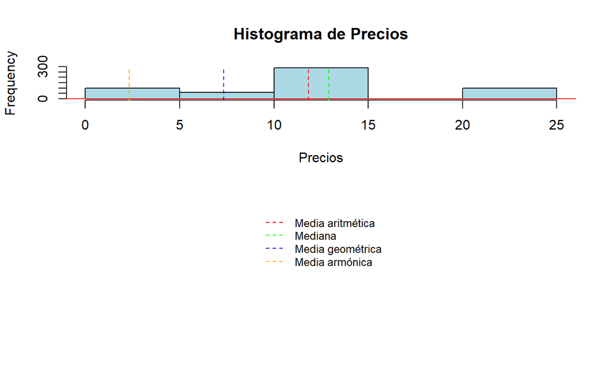

## Revisión

## Revisión

```
## Versión: 30/01/2024
```

## Bibliografía

## Bibliografía

- Business Mathematics.(2023).SBPD https://www.google.com.mx/books/edition/Business_Mathematics/oRLFEAAAQBAJ
- Smith, G. (2015). *Essential statistics, regression, and econometrics.*
- INEGI, (2024). https://repositoriodocumental.ine.mx/xmlui/bitstream/handle/123456789/116274/INE-ACRT-67-2020-a1.pdf